# Credit Card Users Churn Prediction

- There is no big difference in age range for Existing vs Attrited customers
- Attrited customers have lesser dependent count than Existing customers by margin
- Total Relationship count is higher for Attrited customers than Existing customers
- Lesser Months of inactive for Attrited customers than Existing customers
- Contacts count is higher for Attrited customers than Existing customers
- Total Revolving balance is lesser for Attrited customers than Existing customers
- Change in Transaction Amount is lesser for Attrited customers than Existing customers
- Total Transaction Amount is lesser for Attrited customers than Existing customers
- Total Transaction Count follows similar pattern to Total Transaction Amount
- Average Utilization is lesser for Attrited customers than Existing customers

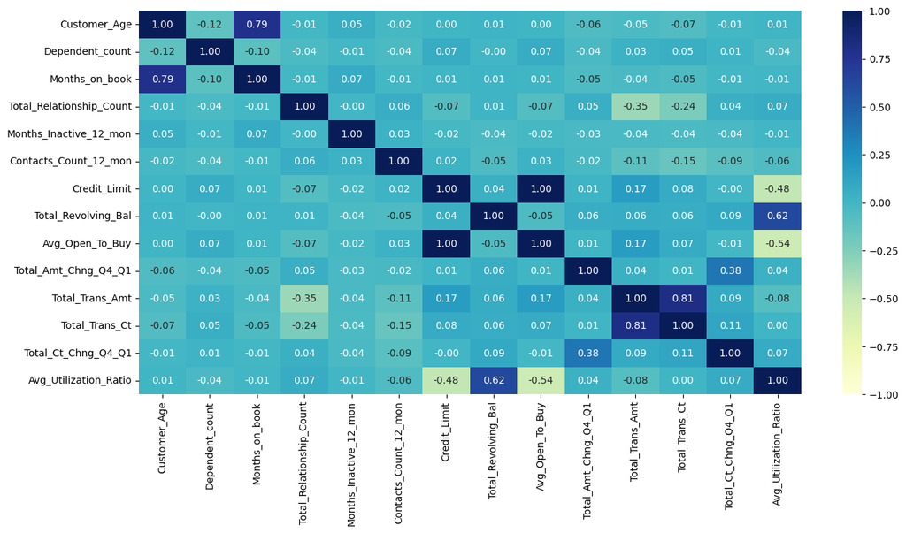

```python
plt.figure(figsize=(15, 7))
sns.heatmap(df[num_cols].corr(), annot=True, vmin=-1, vmax=1, fmt=".2f", cmap="YlGnBu")
plt.show()
```

- Credit Limit and Average Open to Buy have very strong correlation of 1. So, we can drop one of these features
- Customers Age and Months on Book have strong positive correlation
- Total Revolving Balance and Average Utilization Ratio has strong positive correlation
- Total Transaction Amount and Total Transaction count has strong positive correlation
- Average utilization ratio with Average open to buy and credit limit has negative correlation

## Data Pre-processing

```python
#outlier percentage detection
Q1 = df[num_cols].quantile(0.25)  # To find the 25th percentile
Q3 = df[num_cols].quantile(0.75)  # To find the 75th percentile

IQR = Q3 - Q1  # Inter Quantile Range (75th perentile - 25th percentile)

# Finding lower and upper bounds for all values. All values outside these bounds are outliers
lower = (Q1 - 1.5 * IQR)
upper = (Q3 + 1.5 * IQR)
# checking the % outliers
((df.select_dtypes(include=["float64", "int64"]) < lower) | (df.select_dtypes(include=["float64", "int64"]) > upper)).sum() / len(df) * 100
```

```
Customer_Age               0.020
Dependent_count            0.000
Months_on_book             3.812
Total_Relationship_Count   0.000
Months_Inactive_12_mon     3.268
Contacts_Count_12_mon      6.211
Credit_Limit               9.717
Total_Revolving_Bal        0.000
Avg_Open_To_Buy            9.509
Total_Amt_Chng_Q4_Q1       3.910
Total_Trans_Amt            8.848
Total_Trans_Ct             0.020
Total_Ct_Chng_Q4_Q1        3.891
Avg_Utilization_Ratio      0.000
dtype: float64
```

Although, the features have outliers.They are acceptable.Hence, these values can be kept as is.

```python
#Replace strings with integers for Attrition flag category
df['Attrition_Flag'].replace('Attrited Customer',0,inplace = True)
df['Attrition_Flag'].replace('Existing Customer',1,inplace = True)
```

```python
#drop Credit Limit column and create x,y
x = df.drop(['Attrition_Flag','Credit_Limit'],axis = 1)
y = df['Attrition_Flag']
```

```python
#split data to training set, validation set and testing set
x_train,x_temp,y_train,y_temp = train_test_split(x,y,test_size= 0.25,random_state = 1, stratify= y)
x_val,x_test,y_val,y_test = train_test_split(x_temp,y_temp,test_size= 0.25,random_state = 1, stratify= y_temp)
print(x_train.shape, x_val.shape, x_test.shape)
```

```
(7595, 18) (1899, 18) (633, 18)
```

There are 7595 data in training set, 1899 in validation set and 633 in testing set

## Missing value imputation

```python
#checking unique values of education level column
df['Education_Level'].unique()
```

```
array(['High School', 'Graduate', 'Uneducated', nan, 'College',
       'Post-Graduate', 'Doctorate'], dtype=object)
```

```python
#checking unique values of marital status column
df['Marital_Status'].unique()
```

```
array(['Married', 'Single', nan, 'Divorced'], dtype=object)
```

```python
#checking unique values of income category column
df['Income_Category'].unique()
```

```
array(['$60K - $80K', 'Less than $40K', '$80K - $120K', '$40K - $60K',
       '$120K +', 'abc'], dtype=object)
```

```python
#replace abc value with null value
df["Income_Category"].replace("abc", np.nan, inplace=True) ### complete the code to replace the anomalous values with NaN
```

```python
#Imputing null values with mode values
imp_col = ["Education_Level", "Marital_Status", "Income_Category"]
imp_mode = SimpleImputer(missing_values=np.nan,strategy = 'most_frequent')
x_train[imp_col]=imp_mode.fit_transform(x_train[imp_col])
x_val[imp_col]=imp_mode.transform(x_val[imp_col])
x_test[imp_col]=imp_mode.transform(x_test[imp_col])
```

```python
# Checking that no column has missing values in train, validation or test sets
print(x_train.isna().sum())
print("-" * 30)
print(x_val.isna().sum())
print("-" * 30)
print(x_test.isna().sum())
```

```
Customer_Age                0
Gender                      0
Dependent_count             0
Education_Level             0
Marital_Status              0
Income_Category             0
Card_Category               0
Months_on_book              0
Total_Relationship_Count    0
Months_Inactive_12_mon      0
Contacts_Count_12_mon       0
Total_Revolving_Bal         0
Avg_Open_To_Buy             0
Total_Amt_Chng_Q4_Q1        0
Total_Trans_Amt             0
Total_Trans_Ct              0
Total_Ct_Chng_Q4_Q1         0
Avg_Utilization_Ratio       0
dtype: int64
------------------------------
Customer_Age                0
Gender                      0
Dependent_count             0
Education_Level             0
Marital_Status              0
Income_Category             0
Card_Category               0
Months_on_book              0
Total_Relationship_Count    0
Months_Inactive_12_mon      0
Contacts_Count_12_mon       0
Total_Revolving_Bal         0
Avg_Open_To_Buy             0
Total_Amt_Chng_Q4_Q1        0
Total_Trans_Amt             0
Total_Trans_Ct              0
Total_Ct_Chng_Q4_Q1         0
Avg_Utilization_Ratio       0
dtype: int64
------------------------------
Customer_Age                0
Gender                      0
Dependent_count             0
Education_Level             0
Marital_Status              0
Income_Category             0
Card_Category               0
Months_on_book              0
Total_Relationship_Count    0
Months_Inactive_12_mon      0
Contacts_Count_12_mon       0
Total_Revolving_Bal         0
Avg_Open_To_Buy             0
Total_Amt_Chng_Q4_Q1        0
Total_Trans_Amt             0
Total_Trans_Ct              0
Total_Ct_Chng_Q4_Q1         0
Avg_Utilization_Ratio       0
dtype: int64
```

```python
#checking balance ratio of target column
print("Target value ratio in y")
print(y.value_counts(1))
print("*" * 80)
print("Target value ratio in y_train")
print(y_train.value_counts(1))
print("*" * 80)
print("Target value ratio in y_val")
print(y_val.value_counts(1))
print("*" * 80)
print("Target value ratio in y_test")
print(y_test.value_counts(1))
print("*" * 80)
```

```
Target value ratio in y
Attrition_Flag
1   0.839
0   0.161
Name: proportion, dtype: float64
Target value ratio in y_train
Attrition_Flag
1   0.839
0   0.161
Name: proportion, dtype: float64
Target value ratio in y_val
Attrition_Flag
1   0.839
0   0.161
Name: proportion, dtype: float64
Target value ratio in y_test
Attrition_Flag
1   0.839
0   0.161
Name: proportion, dtype: float64
```

```python
#checking counts of different classes of categorical columns in training set
for i in cat_cols:
    if i !='Attrition_Flag':
        print(x_train[i].value_counts())
        print("*" * 30)
```

```
Gender
F    4054
M    3541
Name: count, dtype: int64
Education_Level
Graduate         3467
High School      1514
Uneducated       1127
College           758
Post-Graduate     383
Doctorate         346
Name: count, dtype: int64
Marital_Status
Married     4076
Single      2960
Divorced     559
Name: count, dtype: int64
Income_Category
Less than $40K    2692
$40K - $60K       1316
$80K - $120K      1148
$60K - $80K       1047
abc                855
$120K +            537
Name: count, dtype: int64
Card_Category
Blue        7089
Silver       406
Gold          88
Platinum      12
Name: count, dtype: int64
```

```python
#checking count of different classes of categorical columns in validation set
for i in cat_cols:
    if i !='Attrition_Flag':
      print(x_val[i].value_counts())
      print("*" * 30)
```

```
Gender
F    967
M    932
Name: count, dtype: int64
Education_Level
Graduate         882
High School      381
Uneducated       264
College          180
Post-Graduate    109
Doctorate         83
Name: count, dtype: int64
Marital_Status
Married     1020
Single       733
Divorced     146
Name: count, dtype: int64
Income_Category
Less than $40K    658
$40K - $60K       351
$80K - $120K      280
$60K - $80K       271
abc               189
$120K +           150
Name: count, dtype: int64
Card_Category
Blue        1771
Silver       101
Gold          21
Platinum       6
Name: count, dtype: int64
```

```python
#checking count of different classes of categorical columns in test set
for i in cat_cols:
    if i !='Attrition_Flag':
      print(x_test[i].value_counts())
      print("*" * 30)
```

```
Gender
F    337
M    296
Name: count, dtype: int64
Education_Level
Graduate         298
High School      118
Uneducated        96
College           75
Post-Graduate     24
Doctorate         22
Name: count, dtype: int64
Marital_Status
Married     340
Single      250
Divorced     43
Name: count, dtype: int64
Income_Category
Less than $40K    211
$40K - $60K       123
$80K - $120K      107
$60K - $80K        84
abc                68
$120K +            40
Name: count, dtype: int64
Card_Category
Blue        576
Silver       48
Gold          7
Platinum      2
Name: count, dtype: int64
```

```python
#create one hot encoding for training, validation and test dataset
x_train = pd.get_dummies(x_train, drop_first=True)
x_val = pd.get_dummies(x_val, drop_first=True)
x_test = pd.get_dummies(x_test, drop_first=True)
print(x_train.shape, x_val.shape, x_test.shape)
```

```
(7595, 29) (1899, 29) (633, 29)
```

## Model Building

### Model evaluation criterion

**Let's define a function to output different metrics (including recall) on the train and test set and a function to show confusion matrix so that we do not have to use the same code repetitively while evaluating models.**

```python
# defining a function to compute different metrics to check performance of a classification model built using sklearn
def model_performance_classification_sklearn(model, predictors, target):
    """
    Function to compute different metrics to check classification model performance

    model: classifier
    predictors: independent variables
    target: dependent variable
    """

    # predicting using the independent variables
    pred = model.predict(predictors)

    acc = accuracy_score(target, pred)  # to compute Accuracy
    recall = recall_score(target, pred)  # to compute Recall
    precision = precision_score(target, pred)  # to compute Precision
    f1 = f1_score(target, pred)  # to compute F1-score

    # creating a dataframe of metrics
    df_perf = pd.DataFrame(
        {
            "Accuracy": acc,
            "Recall": recall,
            "Precision": precision,
            "F1": f1

        },
        index=[0],
    )

    return df_perf
```

```python
#defining function for confusion matrix
def confusion_matrix_sklearn(model, predictors, target):
    """
    To plot the confusion_matrix with percentages

    model: classifier
    predictors: independent variables
    target: dependent variable
    """
    y_pred = model.predict(predictors)
    cm = confusion_matrix(target, y_pred)
    labels = np.asarray(
        [
            ["{0:0.0f}".format(item) + "\n{0:.2%}".format(item / cm.flatten().sum())]
            for item in cm.flatten()
        ]
    ).reshape(2, 2)

    plt.figure(figsize=(6, 4))
    sns.heatmap(cm, annot=labels, fmt="")
    plt.ylabel("True label")
    plt.xlabel("Predicted label")
```

### Model Building with original data

```python
models = []  # Empty list to store all the models

# Appending models into the list
models.append(("Bagging", BaggingClassifier(random_state=1)))
models.append(("Random forest", RandomForestClassifier(random_state=1)))
models.append(("Adaboost", AdaBoostClassifier(random_state=1)))
models.append(("Gradient Boosting", GradientBoostingClassifier(random_state=1)))
models.append(("XGBoosting", XGBClassifier(eval_metric='logloss',random_state=1)))

print("\n" "Training Performance:" "\n")
#get recall score for above models in training set
for name, model in models:
    model.fit(x_train, y_train)
    scores = recall_score(y_train, model.predict(x_train))
    print("{}: {}".format(name, scores))

print("\n" "Validation Performance:" "\n")
#get recall score for above models in validation set
for name, model in models:
    model.fit(x_train, y_train)
    scores_val = recall_score(y_val, model.predict(x_val))
    print("{}: {}".format(name, scores_val))
```

```
Training Performance:

Bagging: 0.9978039215686274
Random forest: 1.0
Adaboost: 0.9824313725490196
Gradient Boosting: 0.9927843137254901
XGBoosting: 1.0

Validation Performance:

Bagging: 0.979297365119197
Random forest: 0.9905897114178168
Adaboost: 0.9843161856963614
Gradient Boosting: 0.9899623588456713
XGBoosting: 0.9868255959849436
```

```python
#getting difference between performnce score of training and validation sets
print("\nTraining and Validation Performance Difference:\n")

for name, model in models:
    model.fit(x_train, y_train)
    scores_train = recall_score(y_train, model.predict(x_train))
    scores_val = recall_score(y_val, model.predict(x_val))
    difference = scores_train - scores_val
    print("{}: Training Score: {:.4f}, Validation Score: {:.4f}, Difference: {:.4f}".format(name, scores_train, scores_val, difference))
```

```
Training and Validation Performance Difference:

Bagging: Training Score: 0.9978, Validation Score: 0.9793, Difference: 0.0185
Random forest: Training Score: 1.0000, Validation Score: 0.9906, Difference: 0.0094
Adaboost: Training Score: 0.9824, Validation Score: 0.9843, Difference: -0.0019
Gradient Boosting: Training Score: 0.9928, Validation Score: 0.9900, Difference: 0.0028
XGBoosting: Training Score: 1.0000, Validation Score: 0.9868, Difference: 0.0132
```

### Model Building with Oversampled data

```python
# Synthetic Minority Over Sampling Technique
sm = SMOTE(sampling_strategy=1, k_neighbors=5, random_state=1)
x_train_over, y_train_over = sm.fit_resample(x_train, y_train)
```

```python
#get counts of classes for target variable before and after oversampling
print("Before Oversampling, counts of label 'Yes': {}".format(sum(y_train == 1)))
print("Before Oversampling, counts of label 'No': {} \n".format(sum(y_train == 0)))

print("After Oversampling, counts of label 'Yes': {}".format(sum(y_train_over == 1)))
print("After Oversampling, counts of label 'No': {} \n".format(sum(y_train_over == 0)))

#get count of oversampled training data
print("After Oversampling, the shape of train_x: {}".format(x_train_over.shape))
print("After Oversampling, the shape of train_y: {} \n".format(y_train_over.shape))
```

```
Before Oversampling, counts of label 'Yes': 6375
Before Oversampling, counts of label 'No': 1220

After Oversampling, counts of label 'Yes': 6375
After Oversampling, counts of label 'No': 6375

After Oversampling, the shape of train_x: (12750, 29)
After Oversampling, the shape of train_y: (12750,)
```

```python
models = []  # Empty list to store all the models

# Appending models into the list
models.append(("Bagging", BaggingClassifier(random_state=1)))
models.append(("Random forest", RandomForestClassifier(random_state=1)))
models.append(("Gradient Boosting", GradientBoostingClassifier(random_state=1)))
models.append(("Adaboost", AdaBoostClassifier(random_state=1)))
models.append(("XGBoosting", XGBClassifier(random_state=1)))

#get recall score of oversampled training set
print("\n" "Training Performance:" "\n")
for name, model in models:
    model.fit(x_train_over, y_train_over)
    scores = recall_score(y_train_over, model.predict(x_train_over))
    print("{}: {}".format(name, scores))

#get recall score of oversampled validation set
print("\n" "Validation Performance:" "\n")
for name, model in models:
    model.fit(x_train_over, y_train_over)
    scores = recall_score(y_val, model.predict(x_val))
    print("{}: {}".format(name, scores))
```

```
Training Performance:

Bagging: 0.996078431372549
Random forest: 1.0
Gradient Boosting: 0.9742745098039216
Adaboost: 0.9563921568627451
XGBoosting: 1.0

Validation Performance:

Bagging: 0.9617314930991218
Random forest: 0.973651191969887
Gradient Boosting: 0.9742785445420327
Adaboost: 0.9604767879548306
XGBoosting: 0.9830614805520702
```

```python
#get metrics score difference between oversampled training and validation set
print("\nTraining and Validation Performance Difference:\n")

for name, model in models:

    model.fit(x_train_over, y_train_over)
    scores_train = recall_score(y_train_over, model.predict(x_train_over))
    scores_val = recall_score(y_val, model.predict(x_val))
    difference_over = scores_train - scores_val
    print("{}: Training Score: {:.4f}, Validation Score: {:.4f}, Difference: {:.4f}".format(name, scores_train, scores_val, difference_over))
```

```
Training and Validation Performance Difference:

Bagging: Training Score: 0.9961, Validation Score: 0.9617, Difference: 0.0343
Random forest: Training Score: 1.0000, Validation Score: 0.9737, Difference: 0.0263
Gradient Boosting: Training Score: 0.9743, Validation Score: 0.9743, Difference: -0.0000
Adaboost: Training Score: 0.9564, Validation Score: 0.9605, Difference: -0.0041
XGBoosting: Training Score: 1.0000, Validation Score: 0.9831, Difference: 0.0169
```

### Model Building with Undersampled data

```python
# Random undersampler for under sampling the data
rus = RandomUnderSampler(random_state=1, sampling_strategy=1)
x_train_un, y_train_un = rus.fit_resample(x_train, y_train)
```

```python
#get count of different classes of target variable before and after undersampling
print("Before Under Sampling, counts of label 'Yes': {}".format(sum(y_train == 1)))
print("Before Under Sampling, counts of label 'No': {} \n".format(sum(y_train == 0)))

print("After Under Sampling, counts of label 'Yes': {}".format(sum(y_train_un == 1)))
print("After Under Sampling, counts of label 'No': {} \n".format(sum(y_train_un == 0)))

#get count of undersampled training set
print("After Under Sampling, the shape of train_X: {}".format(x_train_un.shape))
print("After Under Sampling, the shape of train_y: {} \n".format(y_train_un.shape))
```

```
Before Under Sampling, counts of label 'Yes': 6375
Before Under Sampling, counts of label 'No': 1220

After Under Sampling, counts of label 'Yes': 1220
After Under Sampling, counts of label 'No': 1220

After Under Sampling, the shape of train_X: (2440, 29)
After Under Sampling, the shape of train_y: (2440,)
```

```python
models = []  # Empty list to store all the models

# Appending models into the list
models.append(("Bagging", BaggingClassifier(random_state=1)))
models.append(("Random forest", RandomForestClassifier(random_state=1)))
models.append(("Gradient Boosting", GradientBoostingClassifier(random_state=1)))
models.append(("Adaboost", AdaBoostClassifier(random_state=1)))
models.append(("XG Boosting", XGBClassifier(random_state=1)))

#get recall score of undersampled training set
print("\n" "Training Performance:" "\n")
for name, model in models:
    model.fit(x_train_un, y_train_un)
    scores = recall_score(y_train_un, model.predict(x_train_un))
    print("{}: {}".format(name, scores))

#get recall score of validation set
print("\n" "Validation Performance:" "\n")

for name, model in models:
    model.fit(x_train_un, y_train_un)
    scores = recall_score(y_val, model.predict(x_val))
    print("{}: {}".format(name, scores))
```

```
Training Performance:

Bagging: 0.9868852459016394
Random forest: 1.0
Gradient Boosting: 0.9729508196721312
Adaboost: 0.9491803278688524
XG Boosting: 1.0

Validation Performance:

Bagging: 0.9058971141781681
Random forest: 0.9360100376411543
Gradient Boosting: 0.9485570890840652
Adaboost: 0.9328732747804266
XG Boosting: 0.9579673776662484
```

```python
#get metrics score difference between undersampled training and validation set
print("\nTraining and Validation Performance Difference:\n")

for name, model in models:
    model.fit(x_train_un, y_train_un)
    scores_train = recall_score(y_train_un, model.predict(x_train_un))
    scores_val = recall_score(y_val, model.predict(x_val))
    difference_un = scores_train - scores_val
    print("{}: Training Score: {:.4f}, Validation Score: {:.4f}, Difference: {:.4f}".format(name, scores_train, scores_val, difference_un))
```

```
Training and Validation Performance Difference:

Bagging: Training Score: 0.9869, Validation Score: 0.9059, Difference: 0.0810
Random forest: Training Score: 1.0000, Validation Score: 0.9360, Difference: 0.0640
Gradient Boosting: Training Score: 0.9730, Validation Score: 0.9486, Difference: 0.0244
Adaboost: Training Score: 0.9492, Validation Score: 0.9329, Difference: 0.0163
XG Boosting: Training Score: 1.0000, Validation Score: 0.9580, Difference: 0.0420
```

The difference between training and validation score of Bagging, Random Forest, AdaBoost, Gradient Boosting and XGBoosting in original , oversampled and undersampled data is noted. Based on them, AdaBoost with original and oversampled dataset performs well. Similarly, Gradient Boosting with original and oversampled dataset performs well. We select these 4 models to further tune hyperparameters to improve model.

### HyperparameterTuning

#### Sample Parameter Grids

**Note**

1. Sample parameter grids have been provided to do necessary hyperparameter tuning. These sample grids are expected to provide a balance between model performance improvement and execution time. One can extend/reduce the parameter grid based on execution time and system configuration.
   - Please note that if the parameter grid is extended to improve the model performance further, the execution time will increase
- For Gradient Boosting:

```
param_grid = {
    "init": [AdaBoostClassifier(random_state=1),DecisionTreeClassifier(random_state=1)],
    "n_estimators": np.arange(50,110,25),
    "learning_rate": [0.01,0.1,0.05],
    "subsample":[0.7,0.9],
    "max_features":[0.5,0.7,1],
}
```

- For Adaboost:

```
param_grid = {
    "n_estimators": np.arange(50,110,25),
    "learning_rate": [0.01,0.1,0.05],
    "base_estimator": [
        DecisionTreeClassifier(max_depth=2, random_state=1),
        DecisionTreeClassifier(max_depth=3, random_state=1),
    ],
}
```

- For Bagging Classifier:

```
param_grid = {
    'max_samples': [0.8,0.9,1],
    'max_features': [0.7,0.8,0.9],
    'n_estimators' : [30,50,70],
}
```

- For Random Forest:

```
param_grid = {
    "n_estimators": [50,110,25],
    "min_samples_leaf": np.arange(1, 4),
    "max_features": [np.arange(0.3, 0.6, 0.1),'sqrt'],
    "max_samples": np.arange(0.4, 0.7, 0.1)
}
```

- For Decision Trees:

```
param_grid = {
    'max_depth': np.arange(2,6),
    'min_samples_leaf': [1, 4, 7],
    'max_leaf_nodes' : [10, 15],
    'min_impurity_decrease': [0.0001,0.001]
}
```

- For XGBoost (optional):

```
param_grid={'n_estimators':np.arange(50,110,25),
            'scale_pos_weight':[1,2,5],
            'learning_rate':[0.01,0.1,0.05],
            'gamma':[1,3],
            'subsample':[0.7,0.9]
}
```

#### Hyperparameter tuning for AdaBoost with original data

```python
# defining model
Model = AdaBoostClassifier(random_state=1)

# Parameter grid to pass in RandomSearchCV
param_grid = {
    "n_estimators": np.arange(50,110,25),
    "learning_rate": [0.01,0.1,0.05],
    "base_estimator": [
        DecisionTreeClassifier(max_depth=2, random_state=1),
        DecisionTreeClassifier(max_depth=3, random_state=1),
    ],
}


scorer = metrics.make_scorer(metrics.recall_score)


#Calling RandomizedSearchCV
randomized_cv = RandomizedSearchCV(estimator=Model, param_distributions=param_grid, n_iter=10, n_jobs = -1, scoring=scorer, cv=5, random_state=1)

#Fitting parameters in RandomizedSearchCV
randomized_cv.fit(x_train,y_train)

print("Best parameters are {} with CV score={}:" .format(randomized_cv.best_params_,randomized_cv.best_score_))
```

```
Best parameters are {'n_estimators': 100, 'learning_rate': 0.1, 'base_estimator': DecisionTreeClassifier(max_depth=3, random_state=1)} with CV score=0.9893333333333333:
```

```python
# Creating new pipeline with best parameters
adb = AdaBoostClassifier( random_state=1,n_estimators= 100, learning_rate= 0.1, base_estimator= DecisionTreeClassifier(max_depth=3, random_state=1))
adb.fit(x_train,y_train)

adb_train = model_performance_classification_sklearn(adb,x_train,y_train)
print('AdaBoost tuned for training set \n\n',adb_train)

adb_val = model_performance_classification_sklearn(adb,x_val,y_val)
print('AdaBoost tuned for validation set \n\n',adb_val)
```

```
AdaBoost tuned for training set

    Accuracy  Recall  Precision    F1
0     0.984   0.994      0.987 0.990
AdaBoost tuned for validation set

    Accuracy  Recall  Precision    F1
0     0.968   0.992      0.971 0.981
```

#### Hyperparameter tuning for AdaBoost with oversampled data

```python
# defining model
Model = AdaBoostClassifier(random_state=1)

# Parameter grid to pass in RandomSearchCV
param_grid = {
    "n_estimators": np.arange(50,110,25),
    "learning_rate": [0.01,0.1,0.05],
    "base_estimator": [
        DecisionTreeClassifier(max_depth=2, random_state=1),
        DecisionTreeClassifier(max_depth=3, random_state=1),
    ],
}


scorer = metrics.make_scorer(metrics.recall_score)


#Calling RandomizedSearchCV
randomized_cv = RandomizedSearchCV(estimator=Model, param_distributions=param_grid, n_iter=10, n_jobs = -1, scoring=scorer, cv=5, random_state=1)

#Fitting parameters in RandomizedSearchCV
randomized_cv.fit(x_train_over,y_train_over)

print("Best parameters are {} with CV score={}:" .format(randomized_cv.best_params_,randomized_cv.best_score_))
```

```
Best parameters are {'n_estimators': 100, 'learning_rate': 0.1, 'base_estimator': DecisionTreeClassifier(max_depth=3, random_state=1)} with CV score=0.9786666666666667:
```

```python
# Creating new pipeline with best parameters
adb_over = AdaBoostClassifier( random_state=1,n_estimators= 100, learning_rate= 0.1, base_estimator= DecisionTreeClassifier(max_depth=3, random_state=1))
adb_over.fit(x_train_over,y_train_over)

adb_over_train = model_performance_classification_sklearn(adb_over,x_train_over,y_train_over)
print('AdaBoost-oversampled data tuned for training set \n\n',adb_over_train)

adb_over_val = model_performance_classification_sklearn(adb_over,x_val,y_val)
print('AdaBoost-oversampled data tuned for validation set\n\n',adb_over_val)
```

```
AdaBoost-oversampled data tuned for training set

    Accuracy  Recall  Precision    F1
0     0.985   0.985      0.984 0.985
AdaBoost-oversampled data tuned for validation set

    Accuracy  Recall  Precision    F1
0     0.969   0.985      0.979 0.982
```

#### Hyperparameter tuning for Gradient Boosting with original data

```python
# defining model
Model = GradientBoostingClassifier(random_state=1)

# Parameter grid to pass in RandomSearchCV
param_grid = {
    "init": [AdaBoostClassifier(random_state=1),DecisionTreeClassifier(random_state=1)],
    "n_estimators": np.arange(50,110,25),
    "learning_rate": [0.01,0.1,0.05],
    "subsample":[0.7,0.9],
    "max_features":[0.5,0.7,1],
}


scorer = metrics.make_scorer(metrics.recall_score)


#Calling RandomizedSearchCV
randomized_cv = RandomizedSearchCV(estimator=Model, param_distributions=param_grid, n_iter=10, n_jobs = -1, scoring=scorer, cv=5, random_state=1)

#Fitting parameters in RandomizedSearchCV
randomized_cv.fit(x_train,y_train)

print("Best parameters are {} with CV score={}:" .format(randomized_cv.best_params_,randomized_cv.best_score_))
```

```
Best parameters are {'subsample': 0.7, 'n_estimators': 50, 'max_features': 1, 'learning_rate': 0.05, 'init': AdaBoostClassifier(random_state=1)} with CV score=0.9998431372549019:
```

```python
# Creating new pipeline with best parameters
gdb = GradientBoostingClassifier( random_state=1, n_estimators= 50, learning_rate= 0.05, subsample = 0.7, max_features = 1,init= AdaBoostClassifier(random_state=1))
gdb.fit(x_train,y_train)

gdb_train = model_performance_classification_sklearn(gdb,x_train,y_train)
print('Gradient Boosting tuned for training data \n\n',gdb_train)

gdb_val = model_performance_classification_sklearn(gdb,x_val,y_val)
print('Gradient Boosting tuned for validation data \n\n',gdb_val)
```

```
Gradient Boosting tuned for training data

    Accuracy  Recall  Precision    F1
0     0.858   1.000      0.855 0.922
Gradient Boosting tuned for validation data

    Accuracy  Recall  Precision    F1
0     0.854   0.999      0.852 0.920
```

#### Hyperparameter tuning for Gradient Boosting with oversampled data

```python
# defining model
Model = GradientBoostingClassifier(random_state=1)

# Parameter grid to pass in RandomSearchCV
param_grid = {
    "init": [AdaBoostClassifier(random_state=1),DecisionTreeClassifier(random_state=1)],
    "n_estimators": np.arange(50,110,25),
    "learning_rate": [0.01,0.1,0.05],
    "subsample":[0.7,0.9],
    "max_features":[0.5,0.7,1],
}


scorer = metrics.make_scorer(metrics.recall_score)


#Calling RandomizedSearchCV
randomized_cv = RandomizedSearchCV(estimator=Model, param_distributions=param_grid, n_iter=10, n_jobs = -1, scoring=scorer, cv=5, random_state=1)

#Fitting parameters in RandomizedSearchCV
randomized_cv.fit(x_train_over,y_train_over)

print("Best parameters are {} with CV score={}:" .format(randomized_cv.best_params_,randomized_cv.best_score_))
```

```
Best parameters are {'subsample': 0.7, 'n_estimators': 100, 'max_features': 0.7, 'learning_rate': 0.05, 'init': DecisionTreeClassifier(random_state=1)} with CV score=0.9477647058823528:
```

```python
# Creating new pipeline with best parameters
gdb_over = GradientBoostingClassifier( random_state=1,subsample=0.7, n_estimators=100,max_features=0.7,learning_rate=0.05,init=(DecisionTreeClassifier(random_state=1)))
gdb_over.fit(x_train_over,y_train_over)

gdb_over_train = model_performance_classification_sklearn(gdb_over,x_train_over,y_train_over)
print('Gradient Boosting-oversample data tuned for training set \n\n',gdb_over_train)

gdb_over_val = model_performance_classification_sklearn(gdb_over,x_val,y_val)
print('Gradient Boosting-oversample data tuned for validation set \n\n',gdb_over_val)
```

```
Gradient Boosting-oversample data tuned for training set

    Accuracy  Recall  Precision    F1
0     1.000   1.000      1.000 1.000
Gradient Boosting-oversample data tuned for validation set

    Accuracy  Recall  Precision    F1
0     0.937   0.957      0.967 0.962
```

## Model Comparison and Final Model Selection

```python
# training performance comparison

models_train_comp_df = pd.concat(
    [
        adb_train.T,
        adb_over_train.T,
        gdb_train.T,
        gdb_over_train.T
    ],
    axis=1,
)
models_train_comp_df.columns = [
    "AdaBoost trained with original data",
    "AdaBoost trained with Oversampled data",
    "Gradient boosting trained with Original data",
    "Gradient boosting trained with Oversampled data",

    ]
print("Training performance comparison:")
models_train_comp_df
```

```
Training performance comparison:
```

|  | AdaBoost trained with original data | AdaBoost trained with Oversampled data | Gradient boosting trained with Original data | Gradient boosting trained with Oversampled data |
| --- | --- | --- | --- | --- |
| Accuracy | 0.984 | 0.985 | 0.858 | 1.000 |
| Recall | 0.994 | 0.985 | 1.000 | 1.000 |
| Precision | 0.987 | 0.984 | 0.855 | 1.000 |
| F1 | 0.990 | 0.985 | 0.922 | 1.000 |

```python
# validation performance comparison

models_val_comp_df = pd.concat(
    [
        adb_val.T,
        adb_over_val.T,
        gdb_val.T,
        gdb_over_val.T
    ],
    axis=1,
)
models_val_comp_df.columns = [
    "AdaBoost trained with original data",
    "AdaBoost trained with Oversampled data",
    "Gradient boosting trained with Original data",
    "Gradient boosting trained with Oversampled data",

    ]
print("Validation performance comparison:")
models_val_comp_df
```

```
Validation performance comparison:
```

|  | AdaBoost trained with original data | AdaBoost trained with Oversampled data | Gradient boosting trained with Original data | Gradient boosting trained with Oversampled data |
| --- | --- | --- | --- | --- |
| Accuracy | 0.968 | 0.969 | 0.854 | 0.937 |
| Recall | 0.992 | 0.985 | 0.999 | 0.957 |
| Precision | 0.971 | 0.979 | 0.852 | 0.967 |
| F1 | 0.981 | 0.982 | 0.920 | 0.962 |

### Test set final performance

```python
#checking metrics score of AdaBoost model with test dataset
ada_test = model_performance_classification_sklearn(adb, x_test, y_test)
ada_test
```

|  | Accuracy | Recall | Precision | F1 |
| --- | --- | --- | --- | --- |
| 0 | 0.959 | 0.987 | 0.965 | 0.976 |

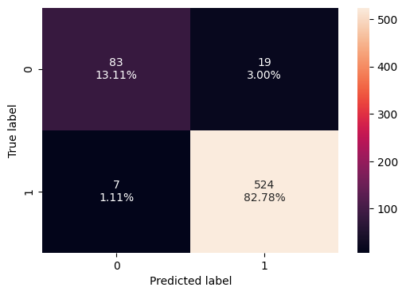

```python
#create confusion matrix with test set
confusion_matrix_sklearn(adb, x_test, y_test)
```

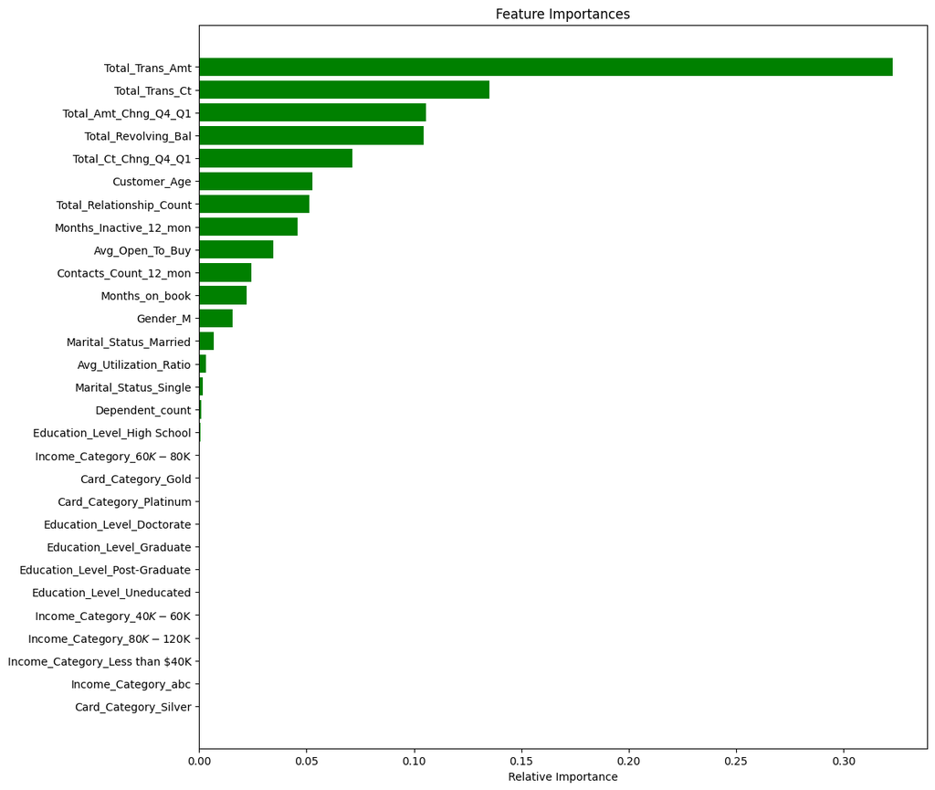

```python
#display feature importances of the model using pictorial representation
feature_names = x_train.columns
importances = adb.feature_importances_
indices = np.argsort(importances)

plt.figure(figsize=(12, 12))
plt.title("Feature Importances")
plt.barh(range(len(indices)), importances[indices], color="green", align="center")
plt.yticks(range(len(indices)), [feature_names[i] for i in indices])
plt.xlabel("Relative Importance")
plt.show()
```

# Business Insights and Conclusions

- Total Transaction Amount and Total Transaction Count features impact attrition of customers
- Personal details such as Gender, Marital Status, Dependent Count does not impact attrition of the customer
- Change in Transaction Amount is lesser for Attrited customers than Existing customers
- Total Transaction Amount is lesser for Attrited customers than Existing customers
- Both Male and Female customers are equally active customers than attrited customers
- The number of Attrited customers who are Doctorate and Post Graduates are higher than other classes.
- Marital status does not have impact on attrition level
- Platinum card holders have more attrition customers than other categories
- Customers with <40K income are the highest group and >120K are the lowest group.
- There are 8500 existing customers out of 10127 customers
- The count of female customers is greater than male customers by 589
- Customers by Location might give more understanding of attrition
- Get Customer Satisfaction Feedback on regular basis and work on the area that needs improvement
- Bank needs to look out when transaction amount changes or there is more revolving balance as it affects attrition rate